# Customize Plots and Graphics

T. C. Hsieh, K. H. Ma, and Anne Chao

2016-03-23

## General customization

The data visualization package [`ggplot2`](http://cran.fhcrc.org/web/packages/ggplot2/index.html) provides `scale_` function to customize data which is mapped into an aesthetic property of a `geom_`. The following functions would help user to customize `ggiNEXT` output.

- change point shape: `scale_shape_manual`
- change line type : `scale_linetype_manual`
- change line color: `scale_colour_manual`
- change band color: `scale_fill_manual`  
  see [quick reference](http://sape.inf.usi.ch/quick-reference/ggplot2/scale) for style setting.

### Example: `spider` data

To show how to custmized `ggiNEXT` output, we use abundance-based data `spider` as an example.

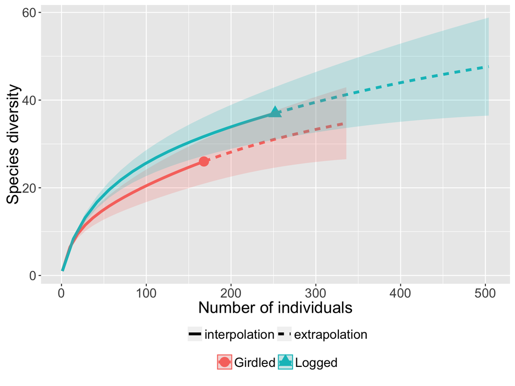

```r
library(iNEXT)
library(ggplot2)
library(gridExtra)
library(grid)
data("spider")
out <- iNEXT(spider, q=0, datatype="abundance")
g <- ggiNEXT(out, type=1, color.var = "site")
g
```

### Change shapes, line types and colors

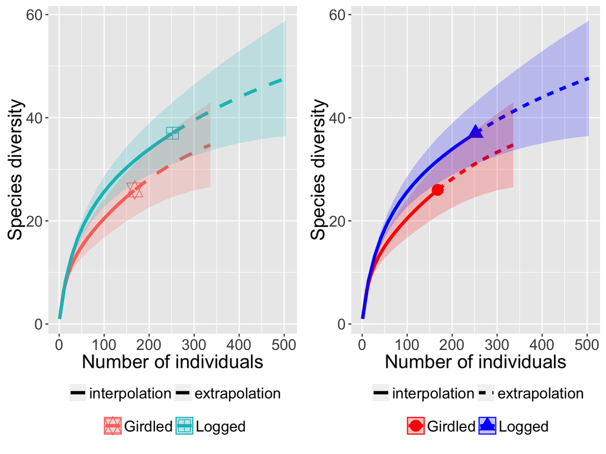

```r
g1 <- g + scale_shape_manual(values=c(11, 12)) +
          scale_linetype_manual(values=c(1,2))
g2 <- g + scale_colour_manual(values=c("red", "blue")) +
          scale_fill_manual(values=c("red", "blue"))

# Draw multiple graphical objec on a page
# library(gridExtra)
grid.arrange(g1, g2, ncol=2)
```

## Customize point/line size by hacking

In order to chage the size of reference sample point or rarefaction/extrapolation curve, user need modify `ggplot` object.

- change point size:  
  the reference sample size point is drawn on the first layer by `ggiNEXT`. Hacking point size by the following

```r
# point is drawn on the 1st layer, default size is 5
gb3 <- ggplot_build(g)
gb3$data[[1]]$size <- 10
gt3 <- ggplot_gtable(gb3)

# use grid.draw to draw the graphical object
# library(grid)
# grid.draw(gt3)
```

```r
# line is drawn on the 2nd layer, default size is 1.5
gb4 <- ggplot_build(g)
gb4$data[[2]]$size <- 3
gt4 <- ggplot_gtable(gb4)
# grid.draw(gt4)
```

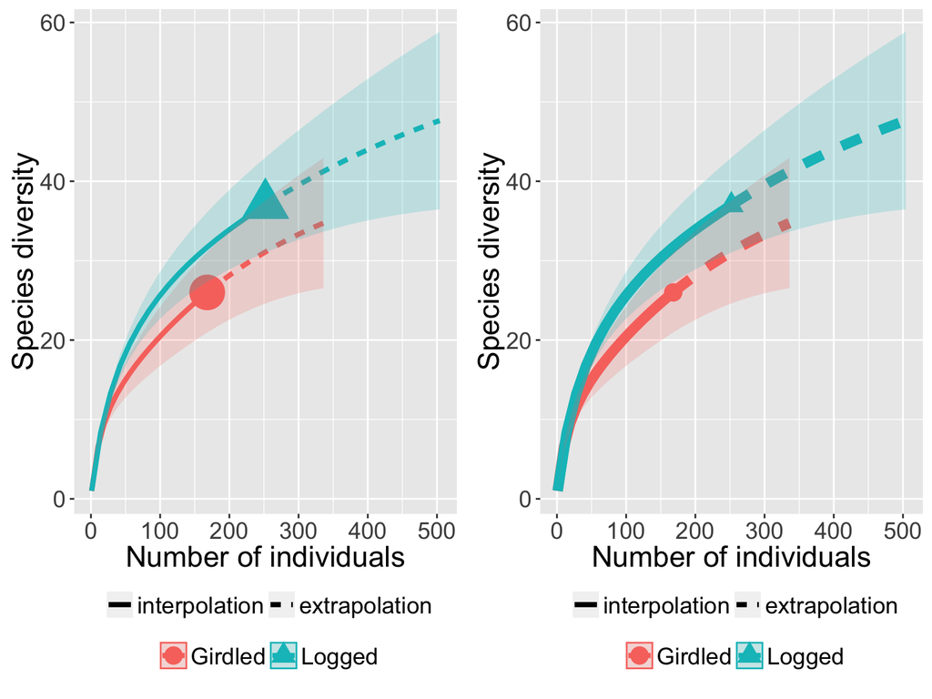

```r
grid.arrange(gt3, gt4, ncol=2)
```

## Customize theme

A `ggplot` object can be themed by adding a theme. User could run `help(theme_grey)` to show the default themes in `ggplot2`. Further, some extra themes provided by [`ggthemes`](http://cran.fhcrc.org/web/packages/ggthemes/index.html) package. Examples shown in the following:

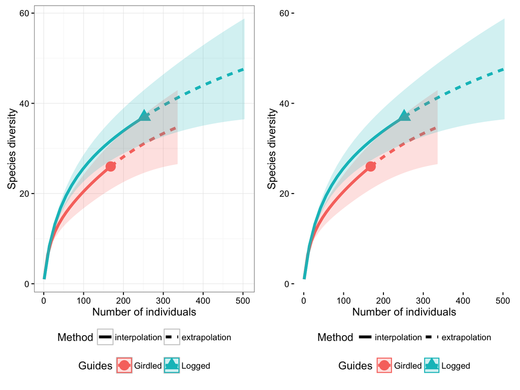

```r
g5 <- g + theme_bw() + theme(legend.position = "bottom")
g6 <- g + theme_classic() + theme(legend.position = "bottom")
grid.arrange(g5, g6, ncol=2)
```

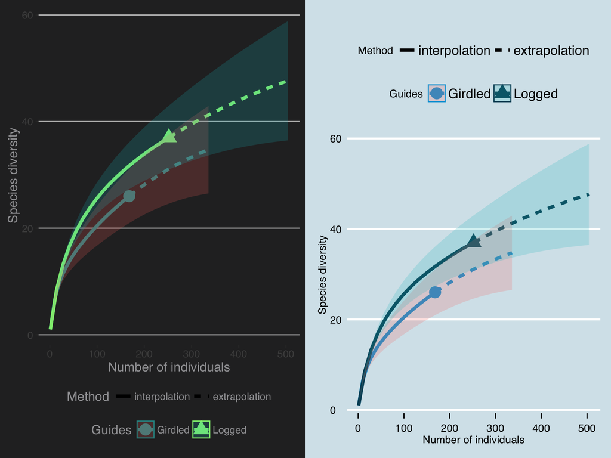

```r
library(ggthemes)
g7 <- g + theme_hc(bgcolor = "darkunica") +
          scale_colour_hc("darkunica")

g8 <- g + theme_economist() + scale_colour_economist()
grid.arrange(g7, g8, ncol=2)
```

### Black-White theme

The following are custmized themes for black-white figure. To modifiy legend, see Cookbook for R for more details.

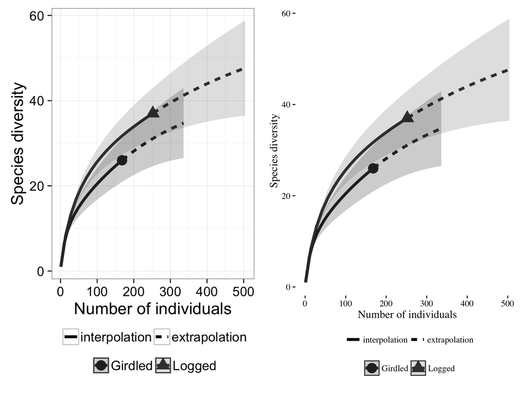

```r
g9 <- g + theme_bw(base_size = 18) +
      scale_fill_grey(start = 0, end = .4) +
      scale_colour_grey(start = .2, end = .2) +
      theme(legend.position="bottom",
            legend.title=element_blank())

g10 <- g + theme_tufte(base_size = 12) +
    scale_fill_grey(start = 0, end = .4) +
    scale_colour_grey(start = .2, end = .2) +
    theme(legend.position="bottom",
          legend.title=element_blank())
grid.arrange(g9, g10, ncol=2)
```

### Draw R/E curves by yourself

In [`iNEXT`](http://cran.fhcrc.org/web/packages/iNEXT/index.html), we provide a S3 `ggplot2::fortify` method for class `iNEXT`. The function `fortify` offers a single plotting interface for rarefaction/extrapolation curves. Set argument `type = 1, 2, 3` to plot the corresponding rarefaction/extrapolation curves.

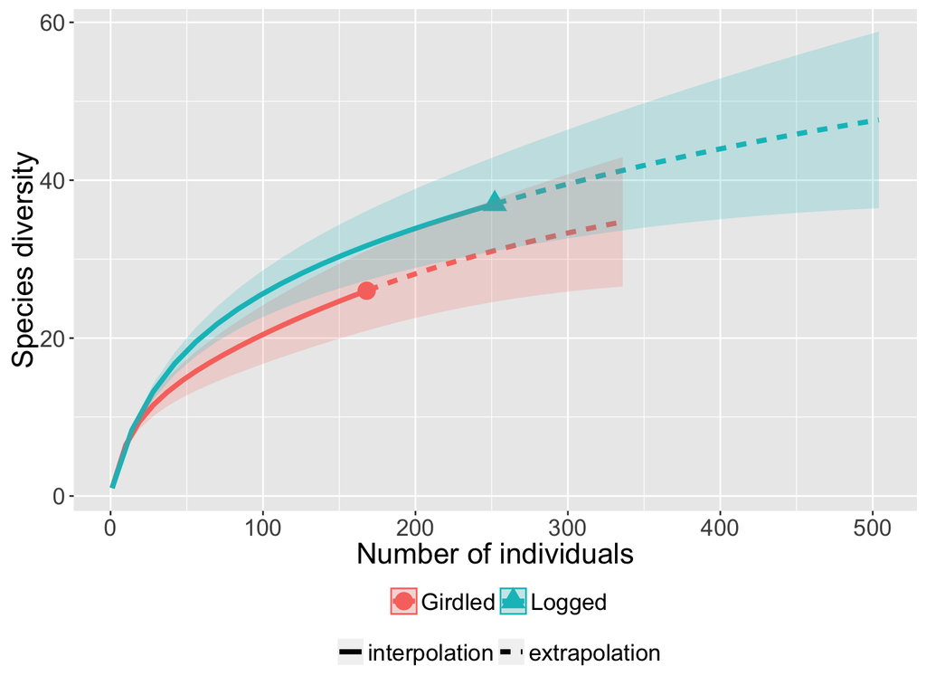

```r
df <- fortify(out, type=1)
head(df)
   datatype plottype    site       method order  x      y  y.lwr  y.upr
1 abundance        1 Girdled interpolated     0  1  1.000  1.000  1.000
2 abundance        1 Girdled interpolated     0 10  6.479  6.003  6.954
3 abundance        1 Girdled interpolated     0 19  9.450  8.489 10.412
4 abundance        1 Girdled interpolated     0 28 11.514 10.120 12.908
5 abundance        1 Girdled interpolated     0 37 13.127 11.348 14.905
6 abundance        1 Girdled interpolated     0 47 14.622 12.462 16.783

df.point <- df[which(df$method=="observed"),]
df.line <- df[which(df$method!="observed"),]
df.line$method <- factor(df.line$method,
                         c("interpolated", "extrapolated"),
                         c("interpolation", "extrapolation"))

ggplot(df, aes(x=x, y=y, colour=site)) +
  geom_point(aes(shape=site), size=5, data=df.point) +
  geom_line(aes(linetype=method), lwd=1.5, data=df.line) +
  geom_ribbon(aes(ymin=y.lwr, ymax=y.upr,
                  fill=site, colour=NULL), alpha=0.2) +
  labs(x="Number of individuals", y="Species diversity") +
  theme(legend.position = "bottom",
        legend.title=element_blank(),
        text=element_text(size=18))
```